# S-R Compatibility Task - Confirmatory Analysis

Milan Ewert, Tim Bax, Niklas Bub, Özge Özenoglu

mewert@uos.de, tbax@uos.de, nbub@uos.de, ooezenoglu@uos.de

July 28, 2020

# Preliminaries

## Load libraries

```r
library(tidyverse)
library(brms)
library(tidybayes)
library(bayesplot)
# devtools::install_github('michael-franke/bayes_mixed_regression_tutorial/faintr',build_vignettes = TRUE)
library(faintr)

options(mc.cores = parallel::detectCores())

color_palette = c("#E69F00", "#56B4E9", "#009E73", "#F0E442", "#0072B2", "#D55E00", "#CC79A7", "#000000")

scale_colour_discrete <- function(...) {
  scale_colour_manual(..., values = color_palette)
}

scale_fill_discrete <- function(...) {
   scale_fill_manual(..., values = color_palette)
}
```

## Load raw data

```r
raw_data <- read.csv('https://raw.githubusercontent.com/ooezenoglu/XPlab-2020-SR-Compatibility/master/data/02_main/01-raw-data-main.csv')

glimpse(raw_data)
```

```
## Rows: 7,650
## Columns: 22
## $ submission_id <int> 1947, 1947, 1947, 1947, 1947, 1947, 1947, 1947, 1947,...
## $ RT            <int> 1249, 2415, 723, 721, 664, 517, 386, 641, 377, 382, 6...
## $ age           <int> 21, 21, 21, 21, 21, 21, 21, 21, 21, 21, 21, 21, 21, 2...
## $ comments      <chr> "", "", "", "", "", "", "", "", "", "", "", "", "", "...
## $ condition     <chr> "incompatible", "incompatible", "incompatible", "inco...
## $ correctness   <chr> "incorrect", "timeout", "correct", "correct", "correc...
## $ education     <chr> "right", "right", "right", "right", "right", "right",...
## $ endTime       <dbl> 1.595887e+12, 1.595887e+12, 1.595887e+12, 1.595887e+1...
## $ expected      <chr> "big", "big", "big", "big", "small", "small", "small"...
## $ experiment_id <int> 155, 155, 155, 155, 155, 155, 155, 155, 155, 155, 155...
## $ gender        <chr> "male", "male", "male", "male", "male", "male", "male...
## $ key_pressed   <chr> "p", "q", "q", "q", "p", "p", "p", "p", "p", "q", "q"...
## $ languages     <chr> "german", "german", "german", "german", "german", "ge...
## $ left          <chr> "big", "big", "big", "big", "big", "big", "big", "big...
## $ order         <chr> "compatible_second", "compatible_second", "compatible...
## $ picture       <chr> "materials/large-stimulus.png", "materials/large-stim...
## $ right         <chr> "small", "small", "small", "small", "small", "small",...
## $ startDate     <chr> "Mon Jul 27 2020 23:48:13 GMT+0200 (MitteleuropÃ¤isch...
## $ startTime     <dbl> 1.595886e+12, 1.595886e+12, 1.595886e+12, 1.595886e+1...
## $ timeSpent     <dbl> 9.075767, 9.075767, 9.075767, 9.075767, 9.075767, 9.0...
## $ trial_number  <int> 1, 2, 3, 4, 5, 6, 7, 8, 9, 10, 1, 2, 3, 4, 5, 6, 7, 8...
## $ trial_type    <chr> "practice", "practice", "practice", "practice", "prac...
```

# Optional participant information

```r
# check summary statistics regarding the age
raw_data %>%
  pull(age) %>%
  summary()
```

```
##    Min. 1st Qu.  Median    Mean 3rd Qu.    Max.    NA's
##   18.00   22.00   24.00   28.12   27.00   61.00     150
```

```r
# check counts within the 'gender' variable
raw_data %>%
  group_by(gender) %>%
  summarise(count = n()/150) %>%
  mutate(gender = c("no answer", "female", "male"))
```

```
## # A tibble: 3 x 2
##   gender    count
##   <chr>     <dbl>
## 1 no answer     1
## 2 female       19
## 3 male         31
```

```r
# check comments of participants
raw_data %>%
  pull(comments) %>%
  unique()
```

```
##  [1] ""
##  [2] "war der bÃ¶rna"
##  [3] "I am writing with my left hand but other than that my right hand is more dominant"
##  [4] "ggs"
##  [5] "Guuuuuuuschhhh <3"
##  [6] "hakuna matatamata"
##  [7] "Ich finde, dass die Zeit zwischen dem Klicken des \"Start\"-Buttons und dem ersten DrÃ¼cken der q bzw p Taste ziemlich kurz ist. Ich weiÃŸ nicht, ob das beabsichtigt ist, aber ich war beide Male noch dabei auf der Tastatur nach der entsprechenden Taste zu suchen als das 4-Eck schon aufgeplo…
##  [8] "NickybÃ¤r"
##  [9] "While completing the second practice round I felt my reactions were slower but once I started the actual test, I felt faster. WHAT IS THIS WIZARDRY!!!? \\n\\nBest of luck in your research endeavors!"
## [10] "I am right handed (English as a first language) and found the first trial a lot more challenging, maybe because I'm used to the -+ for zooming in and out and associate \"right\" with larger"
## [11] "good luck"
```

# Data Wrangling

```r
d <- raw_data %>%
  # rename column name 'education' to 'handedness'
  rename(handedness = education) %>%
  # discard columns not needed for analysis
  select(-picture, -startDate, -startTime, -endTime, -timeSpent, -comments, -gender, -languages)
```

We exclude every individual trial with reaction times below 100 ms and above 1500 ms:

```r
d <- d %>%
  mutate(
    outlier = case_when(RT < 100 ~ TRUE,
                        RT > 1500 ~ TRUE,
                        TRUE ~ FALSE)
  )
```

There are 199 outliers to be excluded.

```r
d <- d %>%
    filter(outlier == FALSE)
```

We exclude all data from practice trials:

```r
d <- d %>%
  filter(trial_type == "main")
```

We only look at correct responses:

```r
d <- d %>%
  filter(correctness == "correct")
```

Given the variables `condition` and `expected`, we create a new variable `correct_response` that will serve as a covariate.

```r
d <- d %>%
mutate(
  # if the condition is 'compatible' and the square is 'big', store the value 'right' in correct_response
  correct_response = ifelse(condition == "compatible" & expected == "big", "right",
                            # if the condition is 'incompatible' and the square is 'small', store the value 'right' in correct_response;
                            # else: store the value 'left' in correct_response (case: compatible, small; incompatible, big)
                            ifelse(condition == "incompatible" & expected == "small", "right", "left"))
)
```

```r
# peek at the first six rows
head(d)
```

```
##   submission_id  RT age    condition correctness handedness expected
## 1          1947 650  21 incompatible     correct      right      big
## 2          1947 478  21 incompatible     correct      right      big
## 3          1947 444  21 incompatible     correct      right    small
## 4          1947 471  21 incompatible     correct      right      big
## 5          1947 485  21 incompatible     correct      right    small
## 6          1947 425  21 incompatible     correct      right      big
##   experiment_id key_pressed left             order right trial_number
## 1           155           q  big compatible_second small            1
## 2           155           q  big compatible_second small            2
## 3           155           p  big compatible_second small            3
## 4           155           q  big compatible_second small            4
## 5           155           p  big compatible_second small            5
## 6           155           q  big compatible_second small            6
##   trial_type outlier correct_response
## 1       main   FALSE             left
## 2       main   FALSE             left
## 3       main   FALSE            right
## 4       main   FALSE             left
## 5       main   FALSE            right
## 6       main   FALSE             left
```

# Summary statistics

```r
# show summary statistics about the reaction time
d %>% pull(RT) %>% summary()
```

```
##    Min. 1st Qu.  Median    Mean 3rd Qu.    Max.
##   251.0   442.0   512.0   547.8   602.0  1492.0
```

```r
d_agg <- d %>%
  # look at each level of 'condition' (compatible, incompatible) and 'correct_response' (left, right)
  group_by(condition, correct_response) %>%
  # get the mean and standard deviation of the reaction time
  summarize(mean_RT = mean(RT),
            sd_RT = sd(RT))

d_agg
```

```
## # A tibble: 4 x 4
## # Groups:   condition [2]
##   condition    correct_response mean_RT sd_RT
##   <chr>        <chr>              <dbl> <dbl>
## 1 compatible   left                534.  143.
## 2 compatible   right               530.  148.
## 3 incompatible left                563.  179.
## 4 incompatible right               563.  174.
```

```r
d_agg_participant <- d %>%
  # look at each level of 'condition' (compatible, incompatible) and 'correct_response' (left, right) for every participant
  group_by(condition, correct_response, submission_id) %>%
  # get the mean and standard deviation of the reaction time
  summarize(mean_RT = mean(RT),
            sd_RT = sd(RT))

# peek at the first six rows
head(d_agg_participant)
```

```
## # A tibble: 6 x 5
## # Groups:   condition, correct_response [1]
##   condition  correct_response submission_id mean_RT sd_RT
##   <chr>      <chr>                    <int>   <dbl> <dbl>
## 1 compatible left                      1652    630. 143.
## 2 compatible left                      1655    531. 129.
## 3 compatible left                      1656    639. 161.
## 4 compatible left                      1657    465.  81.6
## 5 compatible left                      1659    497.  88.5
## 6 compatible left                      1660    406.  31.9
```

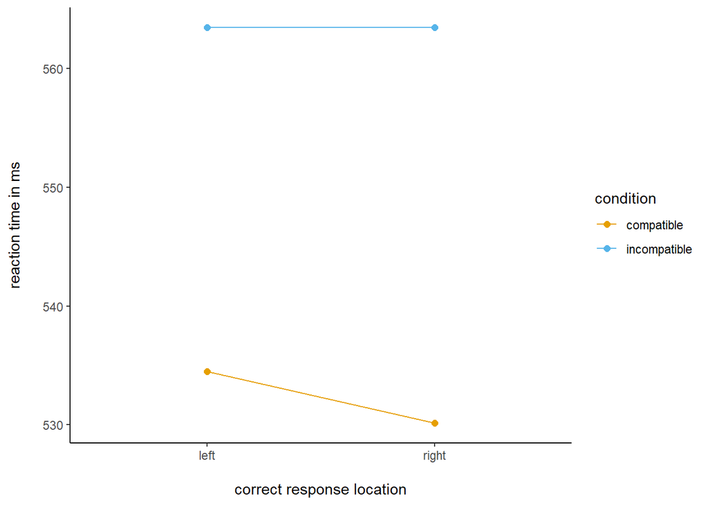

```r
# plot the mean reaction times as a function of 'condition' and 'correct_response'
ggplot(d_agg, aes(x = correct_response, y = mean_RT, color = condition)) +
  geom_point(size = 2) +
  # connect mean reaction times, grouped by 'condition'
  geom_line(aes(group = condition)) +
  xlab("\ncorrect response location") +
  ylab("reaction time in ms\n") +
  theme_classic()
```

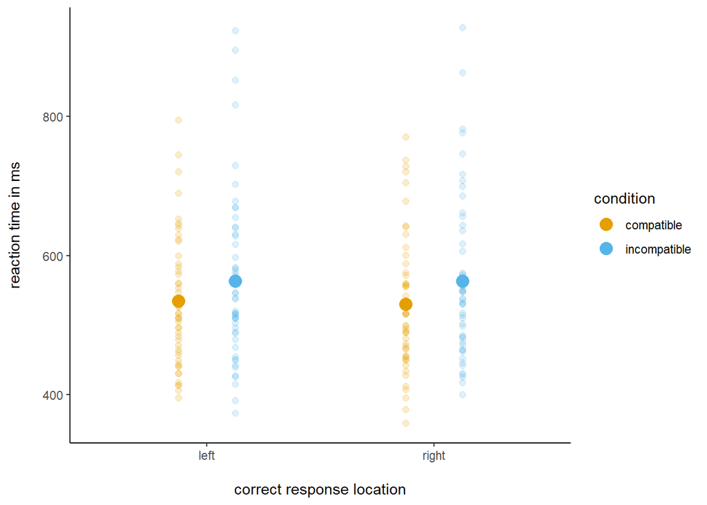

```r
# plot the mean reaction times as a function of 'condition' and 'correct_response'
ggplot(d_agg, aes(x = correct_response, y = mean_RT, color = condition)) +
  geom_point(aes(fill = condition), size = 4, position = position_dodge(width = 0.5)) +
  # add by-participant mean reaction times for each combination of 'condition' and 'correct_response' as semi-transparent points
  geom_point(data = d_agg_participant, aes(x = correct_response, y = mean_RT), size = 2, alpha = 0.2, position = position_dodge(width = 0.5)) +
  xlab("\ncorrect response location") +
  ylab("reaction time in ms\n") +
  theme_classic()
```

# Random effects model

We specify ‘compatible’ as reference level for factor `condition`, and ‘right’ as reference level for factor `correct_response`.

```r
d <- d %>%
    mutate(
      # Treat predictor variables as unordered factors
      condition = factor(condition, levels = c("compatible", "incompatible")),
      correct_response = factor(correct_response, levels = c("right", "left"))
  )

# peek at the first six rows
head(d)
```

```
##   submission_id  RT age    condition correctness handedness expected
## 1          1947 650  21 incompatible     correct      right      big
## 2          1947 478  21 incompatible     correct      right      big
## 3          1947 444  21 incompatible     correct      right    small
## 4          1947 471  21 incompatible     correct      right      big
## 5          1947 485  21 incompatible     correct      right    small
## 6          1947 425  21 incompatible     correct      right      big
##   experiment_id key_pressed left             order right trial_number
## 1           155           q  big compatible_second small            1
## 2           155           q  big compatible_second small            2
## 3           155           p  big compatible_second small            3
## 4           155           q  big compatible_second small            4
## 5           155           p  big compatible_second small            5
## 6           155           q  big compatible_second small            6
##   trial_type outlier correct_response
## 1       main   FALSE             left
## 2       main   FALSE             left
## 3       main   FALSE            right
## 4       main   FALSE             left
## 5       main   FALSE            right
## 6       main   FALSE             left
```

## Model specification

```r
model_RE <- brm(
  formula = RT ~ condition * correct_response + # fixed effects
    (condition * correct_response||submission_id), # random effects
  data = d,
  iter = 3000,
  control = list(adapt_delta = 0.99, max_treedepth = 15),
  seed = 525
)
```

## Posterior estimates

```r
# print model output
model_RE
```

```
##  Family: gaussian
##   Links: mu = identity; sigma = identity
## Formula: RT ~ condition * correct_response + (condition * correct_response || submission_id)
##    Data: d (Number of observations: 5914)
## Samples: 4 chains, each with iter = 3000; warmup = 1500; thin = 1;
##          total post-warmup samples = 6000
##
## Group-Level Effects:
## ~submission_id (Number of levels: 51)
##                                                Estimate Est.Error l-95% CI
## sd(Intercept)                                     93.55      9.62    76.61
## sd(conditionincompatible)                         57.04      7.08    44.87
## sd(correct_responseleft)                          11.37      6.27     0.80
## sd(conditionincompatible:correct_responseleft)    26.30      8.23     9.16
##                                                u-95% CI Rhat Bulk_ESS Tail_ESS
## sd(Intercept)                                    115.05 1.00      922     1739
## sd(conditionincompatible)                         72.26 1.00     2028     3322
## sd(correct_responseleft)                          24.06 1.00     1188     2497
## sd(conditionincompatible:correct_responseleft)    41.88 1.00     1173      792
##
## Population-Level Effects:
##                                            Estimate Est.Error l-95% CI u-95% CI
## Intercept                                    529.85     13.43   503.18   555.70
## conditionincompatible                         33.75      9.13    15.34    51.20
## correct_responseleft                           4.32      4.89    -5.55    14.00
## conditionincompatible:correct_responseleft    -3.24      7.54   -18.23    11.51
##                                            Rhat Bulk_ESS Tail_ESS
## Intercept                                  1.00      498     1382
## conditionincompatible                      1.00     1711     2550
## correct_responseleft                       1.00     6015     4651
## conditionincompatible:correct_responseleft 1.00     4894     4334
##
## Family Specific Parameters:
##       Estimate Est.Error l-95% CI u-95% CI Rhat Bulk_ESS Tail_ESS
## sigma   125.01      1.16   122.76   127.29 1.00     9346     4466
##
## Samples were drawn using sampling(NUTS). For each parameter, Bulk_ESS
## and Tail_ESS are effective sample size measures, and Rhat is the potential
## scale reduction factor on split chains (at convergence, Rhat = 1).
```

```r
# take a look at the chosen priors by brms
prior_summary(model_RE)
```

```
##                       prior     class
## 1                                   b
## 2                                   b
## 3                                   b
## 4                                   b
## 5  student_t(3, 512, 114.2) Intercept
## 6    student_t(3, 0, 114.2)        sd
## 7                                  sd
## 8                                  sd
## 9                                  sd
## 10                                 sd
## 11                                 sd
## 12   student_t(3, 0, 114.2)     sigma
##                                          coef         group resp dpar nlpar
## 1
## 2                       conditionincompatible
## 3  conditionincompatible:correct_responseleft
## 4                        correct_responseleft
## 5
## 6
## 7                                             submission_id
## 8                       conditionincompatible submission_id
## 9  conditionincompatible:correct_responseleft submission_id
## 10                       correct_responseleft submission_id
## 11                                  Intercept submission_id
## 12
##    bound
## 1
## 2
## 3
## 4
## 5
## 6
## 7
## 8
## 9
## 10
## 11
## 12
```

```r
# extract posterior samples
parameter_values <- posterior_samples(model_RE) %>%
  round(3) %>%
  # select coefficients of interest (population-level effects)
  select(b_Intercept,
         b_conditionincompatible,
         b_correct_responseleft,
         `b_conditionincompatible:correct_responseleft`) %>%
  # cast output into tidy format
  pivot_longer(cols = everything(), names_to = "parameter", values_to = "value") %>%
  select(parameter, value)

# peek at the first six rows
head(parameter_values)
```

```
## # A tibble: 6 x 2
##   parameter                                     value
##   <chr>                                         <dbl>
## 1 b_Intercept                                  538.
## 2 b_conditionincompatible                       42.9
## 3 b_correct_responseleft                        -8.63
## 4 b_conditionincompatible:correct_responseleft  -5.59
## 5 b_Intercept                                  537.
## 6 b_conditionincompatible                       36.3
```

```r
# store model output in a tibble
parameter_summary <- model_RE %>%
  spread_draws(b_Intercept,
               b_conditionincompatible,
               b_correct_responseleft,
               `b_conditionincompatible:correct_responseleft`) %>%
  mean_qi()

# extract the mean posterior estimates in a tidy format
mean_values <- parameter_summary %>%
  pivot_longer(cols = c(b_Intercept, b_conditionincompatible, b_correct_responseleft,
                        `b_conditionincompatible:correct_responseleft`),
               names_to = "parameter",
               values_to = "mean") %>%
  select(parameter, mean)

# extract the lower bounds of the 95% credible intervals in a tidy format
lowerHDI <- parameter_summary %>%
  pivot_longer(cols = contains("lower"),
               names_to = "parameter_lower",
               values_to = "lower") %>%
  select(parameter_lower, lower)

# extract the upper bounds of the 95% credible intervals in a tidy format
upperHDI <- parameter_summary %>%
  pivot_longer(cols = contains("upper"),
               names_to = "parameter_upper",
               values_to = "upper") %>%
  select(parameter_upper, upper)

# combine mean posterior estimates, lower 95% CrI, upper 95% CrI in one tibble
coefficients <- cbind(mean_values, lowerHDI, upperHDI) %>%
  select(-contains(c("_lower", "_upper")))


coefficients
```

```
##                                      parameter       mean      lower     upper
## 1                                  b_Intercept 529.847996 503.184699 555.69666
## 2                      b_conditionincompatible  33.746283  15.342502  51.19535
## 3                       b_correct_responseleft   4.316393  -5.548007  14.00443
## 4 b_conditionincompatible:correct_responseleft  -3.244671 -18.232458  11.50734
```

The following plot is inspired by a tutorial of Michael Franke and Timo Röttger (2019)[^1].

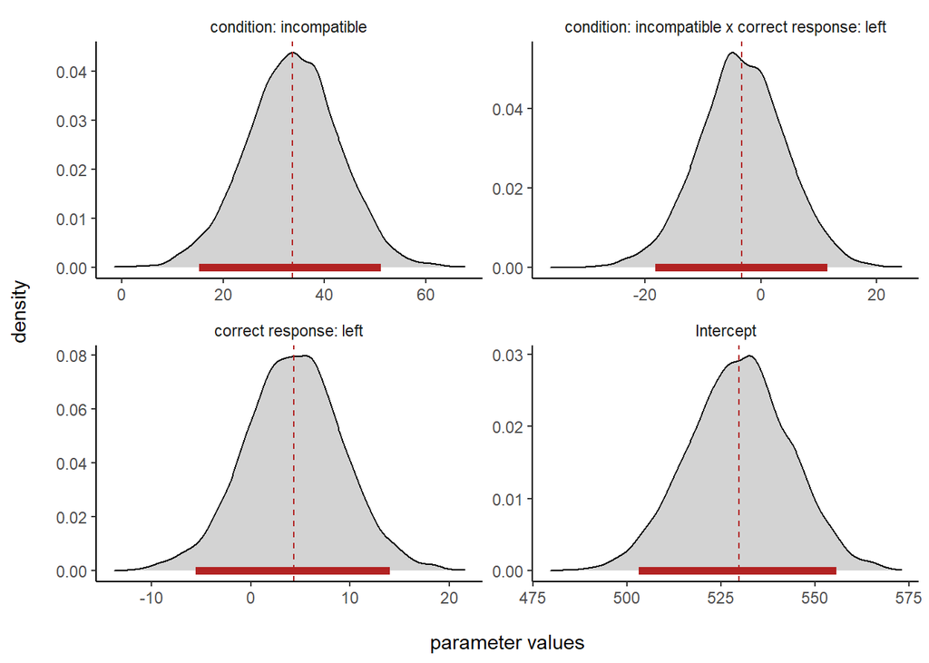

```r
# specify new label names for facet_wrap
new_labels <- c("b_Intercept" = "Intercept",
                "b_conditionincompatible" = "condition: incompatible",
                "b_correct_responseleft" = "correct response: left",
                "b_conditionincompatible:correct_responseleft" = "condition: incompatible x correct response: left")

# create a density plot for all parameter values of the coefficients estimated by the model
ggplot(data = parameter_values, mapping = aes(x = value)) +
  facet_wrap(.~parameter, scales = "free", labeller = labeller(parameter = new_labels))  +
  geom_density(fill = "lightgrey") +
  # add mean posterior estimates as dashed, red lines
  geom_vline(data = coefficients, mapping = aes(xintercept = mean), color = "firebrick", lty = "dashed") +
  # mark the 95% credible interall for all coefficients
  geom_segment(data = coefficients, mapping = aes(x = lower,xend = upper,y = 0,yend = 0), size = 2, color = "firebrick") +
  xlab("\nparameter values") +
  ylab("density\n") +
  theme_classic() +
  theme(strip.background = element_blank())
```

```r
# Extract the posterior estimates
derived_posteriors <- model_RE %>%
  spread_draws(b_Intercept,
               b_conditionincompatible,
               b_correct_responseleft,
               `b_conditionincompatible:correct_responseleft`) %>%
  # Calculate posteriors for each individual level
  mutate(Compatible_right = b_Intercept,
         Compatible_left = b_Intercept + b_correct_responseleft,
         Incompatible_right = b_Intercept + b_conditionincompatible,
         Incompatible_left = b_Intercept + b_conditionincompatible + b_correct_responseleft +
                              `b_conditionincompatible:correct_responseleft`) %>%
  # select relevant columns
  select(Compatible_right, Compatible_left, Incompatible_right, Incompatible_left) %>%
  gather(key = "parameter", value = "posterior") %>%
  # create a new column 'correct_response' (values: right, left)
  # if the current value in 'parameter' contains the string 'right', store 'right' in correct_response; else: 'left'
  mutate(correct_response = ifelse(parameter == "Compatible_right" | parameter == "Incompatible_right",
                        "right", "left"),
         # create a new column 'condition' (values: compatible, incompatible)
         # if the current value in 'parameter' contains the string 'Compatible, store 'compatible' in condition; else: 'incompatible'
          condition = ifelse(parameter == "Compatible_right" | parameter == "Compatible_left",
                        "compatible", "incompatible"))


# summarize posterior means and 95% Credible Intervals for each condition
posteriors_agg <- derived_posteriors %>%
  group_by(condition) %>%
  summarise(`|95%` = HDInterval::hdi(posterior, credMass = 0.95)[1],
            mean_posterior = mean(posterior),
            `95%|` = HDInterval::hdi(posterior, credMass = 0.95)[2])

posteriors_agg
```

```
## # A tibble: 2 x 4
##   condition    `|95%` mean_posterior `95%|`
##   <chr>         <dbl>          <dbl>  <dbl>
## 1 compatible     505.           532.   558.
## 2 incompatible   533.           564.   595.
```

```r
# summarize posterior means and 95% Credible Intervals for each combination of condition and correct_response
posteriors_agg2 <- derived_posteriors %>%
  group_by(correct_response, condition) %>%
  summarise(`|95%` = HDInterval::hdi(posterior, credMass = 0.95)[1],
            mean_posterior = mean(posterior),
            `95%|` = HDInterval::hdi(posterior, credMass = 0.95)[2])

posteriors_agg2
```

```
## # A tibble: 4 x 5
## # Groups:   correct_response [2]
##   correct_response condition    `|95%` mean_posterior `95%|`
##   <chr>            <chr>         <dbl>          <dbl>  <dbl>
## 1 left             compatible     507.           534.   561.
## 2 left             incompatible   534.           565.   596.
## 3 right            compatible     504.           530.   556.
## 4 right            incompatible   533.           564.   593.
```

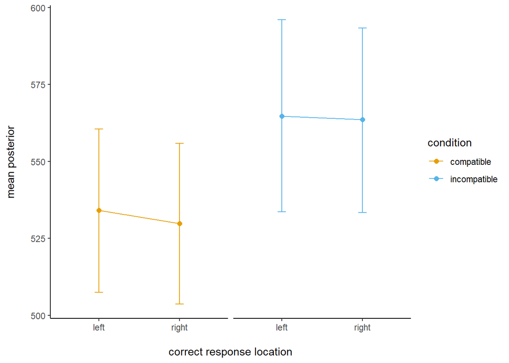

```r
posteriors_agg2 %>%
  ggplot(aes(x = correct_response, y = mean_posterior, color = condition)) +
  facet_wrap(.~condition) +
  # plot the mean posterior estimates as a function of 'correct_response' and 'condition'
  geom_point(size = 2) +
  # ad the 95% credible intervals for each combination of 'correct_response' and 'condition'
  geom_errorbar(aes(ymin = `|95%`, ymax = `95%|`), width = 0.1) +
  # connect mean posterior estimates, grouped by 'condition'
  geom_line(aes(group = condition)) +
  theme_classic() +
  theme(strip.background = element_blank(), strip.text.x = element_blank()) +
  xlab("\ncorrect response location") +
  ylab("mean posterior\n")
```

# Hypothesis Testing

## Hypothesis 1

> Response times are faster in the compatible mapping condition than in the incompatible mapping condition.

```r
compare_groups(
  model = model_RE,
  higher = list("condition" = "incompatible"),
  lower = list("condition" = "compatible")
)
```

```
## Outcome of comparing groups:
##  * higher:  condition:incompatible
##  * lower:   condition:compatible
## Mean 'higher - lower':  32.12
## 95% CI: [ 13.71 ; 48.49 ]
## P('higher - lower' > 0):  0.9997
```

## Hypothesis 2

> The compatible S-R mapping yields faster reaction times for right-responses than for left-responses.

```r
compare_groups(
  model = model_RE,
  higher = list(condition = "compatible", correct_response = "left"),
  lower = list(condition = "compatible", correct_response = "right")
)
```

```
## Outcome of comparing groups:
##  * higher:  condition:compatible correct_response:left
##  * lower:   condition:compatible correct_response:right
## Mean 'higher - lower':  4.316
## 95% CI: [ -4.783 ; 14.63 ]
## P('higher - lower' > 0):  0.8147
```

## Hypothesis 3

> The incompatible S-R mapping yields slower reaction times for right-responses than for left-responses.

```r
compare_groups(
  model = model_RE,
  higher = list(condition = "incompatible", correct_response = "right"),
  lower = list(condition = "incompatible", correct_response = "left")
)
```

```
## Outcome of comparing groups:
##  * higher:  condition:incompatible correct_response:right
##  * lower:   condition:incompatible correct_response:left
## Mean 'higher - lower':  -1.072
## 95% CI: [ -13.95 ; 10.84 ]
## P('higher - lower' > 0):  0.433
```

[^1]: Franke, M., & Roettger, T. B. (2019, July 13). Bayesian regression modeling (for factorial designs): A tutorial. https://doi.org/10.31234/osf.io/cdxv3